# Customer Movie Rating Clustering Using K-Means Clustering

Ikhwanul Muslimin

4/26/2021

# Masalah

Diberikan file customer_movie_rating.csv, lakukan segmentasi pelanggan dengan menggunakan K-Means Clustering, kemudian pilih nilai k terbaik dan analisa hasil setiap klaster.

# Solusi

## Load Library dan Data

```r
library(NbClust)
library(factoextra)

df = read.csv('customer_movie_rating.csv')
```

## Eksplorasi Data

Bentuk data:

```
##   Horror Romcom Action Comedy Fantasy
## 1   72.5   29.9   68.6   40.7    57.9
## 2   82.2   45.3   76.5   17.4    67.7
## 3   70.0   44.0   65.1   53.7    37.8
## 4   99.1   21.0   77.9   25.4    40.3
## 5   84.0    0.0   68.1   49.8    40.0
## 6   70.2   55.0   97.2   48.1    40.5
```

Dengan dimensi:

```
## [1] 291   5
```

Informasi umum data:

```
##      Horror           Romcom          Action           Comedy
##  Min.   :  0.00   Min.   : 0.00   Min.   : 24.60   Min.   :  0.00
##  1st Qu.: 40.00   1st Qu.:19.90   1st Qu.: 58.75   1st Qu.: 38.50
##  Median : 62.80   Median :29.70   Median : 70.50   Median : 60.00
##  Mean   : 58.57   Mean   :31.25   Mean   : 68.84   Mean   : 56.52
##  3rd Qu.: 78.25   3rd Qu.:41.65   3rd Qu.: 80.55   3rd Qu.: 73.45
##  Max.   :100.00   Max.   :81.30   Max.   :100.00   Max.   :100.00
##     Fantasy
##  Min.   :  0.00
##  1st Qu.: 28.95
##  Median : 41.20
##  Mean   : 45.61
##  3rd Qu.: 59.85
##  Max.   :100.00
```

Dari hasil di atas, dapat dilihat bahwa data yang kita miliki merupakan rating yang diberikan pelanggan untuk setiap genre film dalam sebuah website. Terdapat **5 genre film** yang akan ditinjau: Horror, Romcom, Action, Comedy, dan Fantasy di mana masing-masingnya memiliki nilai yang berada pada rentang **0 - 100**. Dalam kasus ini, data kita memiliki satuan yang sama, sehingga **tidak perlu melakukan penskalaan** lagi.

## Mencari Nilai $k$ yang Optimal

```
## [1] "Frey index : No clustering structure in this data set"
```

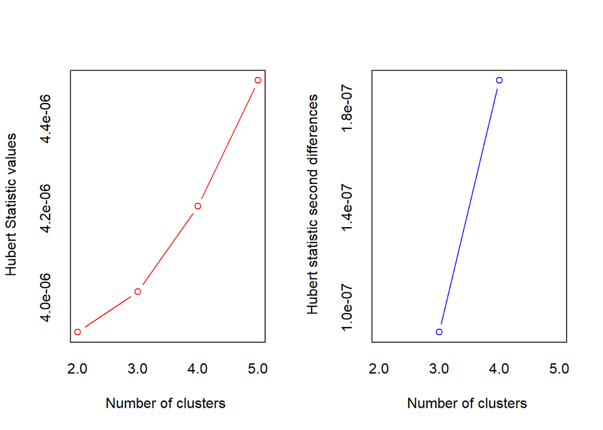

```
## *** : The Hubert index is a graphical method of determining the number of clusters.
##                 In the plot of Hubert index, we seek a significant knee that corresponds to a
##                 significant increase of the value of the measure i.e the significant peak in Hubert
##                 index second differences plot.
##
```

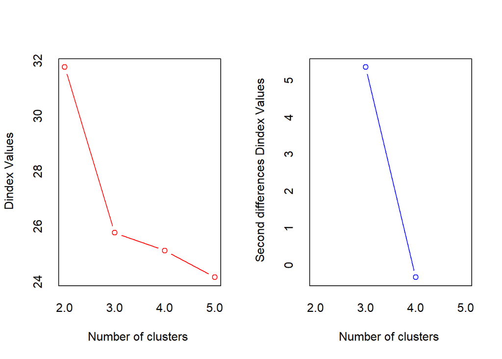

```
## *** : The D index is a graphical method of determining the number of clusters.
##                 In the plot of D index, we seek a significant knee (the significant peak in Dindex
##                 second differences plot) that corresponds to a significant increase of the value of
##                 the measure.
##
## * Among all indices:
## * 9 proposed 2 as the best number of clusters
## * 12 proposed 3 as the best number of clusters
## * 1 proposed 4 as the best number of clusters
## * 1 proposed 5 as the best number of clusters
##
##                    ***** Conclusion *****
##
## * According to the majority rule, the best number of clusters is  3
##
##
```

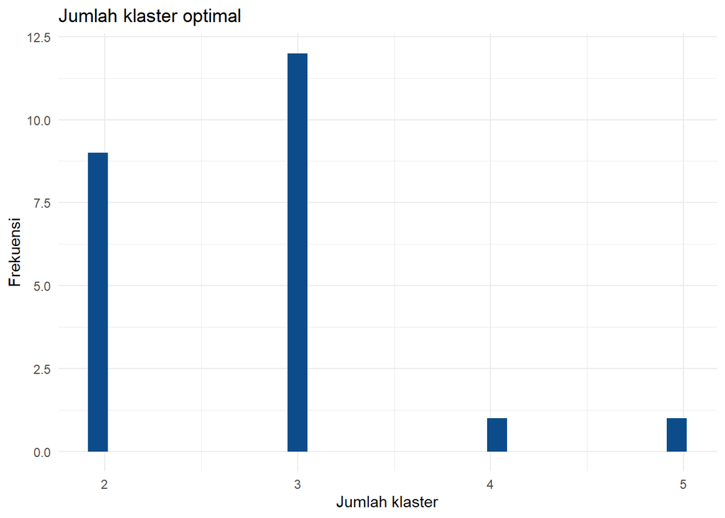

## K-Means Clustering dengan $k=3$

Berikut adalah visualisasi *clustering* yang paling optimal untuk kasus di atas:

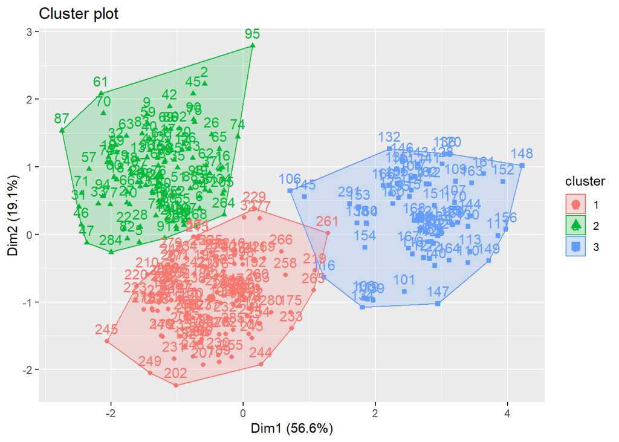

Salah satu parameter yang digunakan untuk menentukan kualitas dari hasil *K-Means Clustering* ini adalah perbandingan antara BSS (*Between Sum of Squares*) dan TSS (*Total Sum of Squares*),
$$\frac{BSS}{TSS}\times 100$$
Untuk kasus $k=3$, diperoleh kualitasnya sebesar:

```
## [1] 65.84033
```